ML Research · International Day Pass Pricing

# From customer response models to a price recommendation

Estimating the 12-month revenue effect of a proposed international roaming price increase

## Disclosure

- This notebook reconstructs the methodology used in a client engagement for portfolio purposes. It does not reproduce the engagement or its results.
- The $100 million contribution described in the Introduction provides business context and is not a modeled result.
- All data and modeled results are synthetic. The approximately 50,000-account customer base was designed to support the same type of modeling methodology. All coefficients, distributions, revenue estimates, and segment profiles are derived from synthetic data and do not reflect the engagement’s actual findings.
- The actual findings, production Power BI deliverable, and client-identifying details are proprietary and are not reproduced here.
- What remains faithful to the original work is the methodology, including the model architecture, estimation choices, simulation design, and segmentation logic.

## Abstract

- This study evaluates a proposed international roaming price increase using a synthetic book of approximately 50,000 accounts. It estimates the resulting 12-month roaming revenue and identifies the customers most likely to reduce or stop purchasing roaming coverage.
- Two machine-learning models estimate how customers respond to price. The first predicts whether a trip receives no, partial, or full coverage, while the second estimates how much coverage is purchased when a customer reduces usage. A simulation then evaluates revenue across a range of prices and economic conditions.
- The recommendation is read directly from the as-fitted models — the study's expected-case output, with no sensitivity adjustment. The study separately runs a joint stronger-response sensitivity as a disclosed robustness check, not as the basis for the price decision, because two diagnostics suggest the fitted models may understate both price response and reduction depth.
- Account segments respond differently enough that letting each take its own best price beats a single uniform increase by roughly $79,000 a year in modeled gross revenue, chiefly by holding the most price-sensitive segments near the standard price. That figure carries no implementation or fairness cost, so segmentation informs the pricing decision more than it settles it, while also showing where retention effort belongs.
- Under the as-fitted model, modeled 12-month roaming revenue is still rising at the top of the evaluated range. The recommendation is therefore a **20% increase**, the highest price the study evaluated: it describes the best price within the study's permitted range, not a proven unconstrained optimum. Under the joint stronger-response sensitivity robustness check, the same curve instead peaks at 15%; that result is disclosed as a limitation rather than incorporated into the price selection.
- Because the synthetic book is a small illustrative sample, its modeled dollar figures are also scaled against an independent, real-world anchor — U.S. Department of Commerce international air-travel statistics — under a disclosed 30% assumed carrier market share. At the recommended price, that scale-up lands at roughly $102 million against the $100 million company-wide target the study was assigned (Section 5.1).
- The results are packaged as a Power BI-ready star schema — precomputed tables, relationships, and measure definitions — so a scenario model over price, customer mix, and economic conditions can be built from the study outputs without rerunning it.

## Introduction

**Business Question:** International roaming was assigned a $100 million contribution toward closing a larger company-wide revenue gap. How much of that target could be delivered through a price change, and how would different customer groups be affected?

**Data and Scope:** The study uses a synthetic customer base of approximately 50,000 accounts, built and validated in a separate data notebook. It estimates the effect on roaming revenue over 12 months. Wireless churn (customers leaving the carrier entirely) is outside the scope of this study; the results describe roaming-pass revenue, not total customer value.

**Study Design:** The study follows four connected stages, with each stage supplying the information required by the next.

| Section | Business Question Answered |
| --- | --- |
| 01 · Customer Response (State Model) | How likely is a customer to choose no, partial, or full roaming coverage for a trip at each candidate price? |
| 02 · Purchase Amount (Magnitude Model) | When a customer chooses partial coverage, how much roaming coverage will be purchased? |
| 03 · 12-Month Revenue Simulation | How much 12-month roaming revenue could result at each price under different economic and market conditions, under both the fitted models and the joint stronger-response sensitivity? |
| 04 · Customer Segments and Delivery | Which customer groups are most affected, and how are the results packaged for a downstream Power BI scenario model? |

**Model Requirements:** Because the predicted probabilities enter directly into the revenue calculation, they must be well calibrated, not merely useful for ranking customers. The price-response curves must also be monotonic and smooth, ensuring that simulated customer behavior remains economically coherent across the full range of candidate prices.

## Initialize Environment

Initializes the shared imports, plotting style, file paths, constants, and helper functions used throughout the study. Each section then loads only the data and defines only the components it requires.

```python
# Standard Library
from pathlib import Path

# Numerical and Data
import numpy as np
import pandas as pd

# Visualization
import matplotlib.pyplot as plt

# Optimization
from scipy.optimize import minimize

# Scikit-Learn: Models
from sklearn.cluster import KMeans
from sklearn.ensemble import HistGradientBoostingClassifier, HistGradientBoostingRegressor
from sklearn.linear_model import LogisticRegression

# Scikit-Learn: Preprocessing and Calibration
from sklearn.preprocessing import StandardScaler
from sklearn.calibration import calibration_curve
from sklearn.isotonic import IsotonicRegression

# Scikit-Learn: Metrics
from sklearn.metrics import (
    adjusted_mutual_info_score,
    adjusted_rand_score,
    brier_score_loss,
    log_loss,
    mean_absolute_error,
    r2_score,
    roc_auc_score,
    silhouette_score,
)

# Jupyter
from IPython.display import display
```

```python
# Plotting Theme and Color Palette
SURFACE = '#ffffff'
INK = '#0b0b0b'
MUTED = '#898781'
GRIDLINE = '#e1e0d9'
BASELINE = '#c3c2b7'
ACCENT = '#2a78d6'
ACCENT2 = '#eb6834'
RED = '#e34948'
PALETTE = [ACCENT, '#17369b', '#6f8fe8', RED, MUTED, INK]

plt.rcParams.update({
    'figure.dpi': 110,
    'figure.facecolor': SURFACE,
    'axes.facecolor': SURFACE,
    'savefig.facecolor': SURFACE,
    'axes.edgecolor': BASELINE,
    'axes.spines.top': False,
    'axes.spines.right': False,
    'axes.grid': False,
    'grid.color': GRIDLINE,
    'grid.linewidth': 0.8,
    'font.size': 9,
    'text.color': INK,
    'axes.labelcolor': INK,
    'xtick.color': MUTED,
    'ytick.color': MUTED,
})
```

```python
# Data Loading and Export Helpers
DATA = Path('data/synthetic')

def load(name):

    pq, csv = DATA / f'{name}.parquet', DATA / f'{name}.csv'
    if pq.exists():
        return pd.read_parquet(pq)

    if csv.exists():
        return pd.read_csv(csv)

    raise FileNotFoundError(
        f'{name} not found in {DATA.resolve()}. Run '
        'data/00_generate_and_validate_data.ipynb, then the earlier sections, first.')


def _parquet_available():

    for mod in ('pyarrow', 'fastparquet'):
        try:
            __import__(mod)
            return True

        except ImportError:
            continue

    print('pyarrow/fastparquet not found; writing CSV instead.')

    return False


FMT = 'parquet' if _parquet_available() else 'csv'

def save_tables(frames, dest = DATA, with_cols = False):

    dest = Path(dest)
    dest.mkdir(parents = True, exist_ok = True)

    names, rows, cols = [], [], []
    for name, df in frames.items():
        path = dest / f'{name}.{FMT}'
        df.to_parquet(path, index = False) if FMT == 'parquet' else df.to_csv(path, index = False)
        names.append(path.name)
        rows.append(len(df))
        cols.append(df.shape[1])

    data = {'rows': rows, 'cols': cols} if with_cols else {'rows': rows}

    return pd.DataFrame(data, index = names).rename_axis(None)
```

```python
# Domain Constants and Data-Preparation Helpers
CLASSES = ['null', 'partial', 'full']
IDX = {c: i for i, c in enumerate(CLASSES)}
DAY_THRESH = 0.70
PRICE_FIRST, PRICE_ADDL = 10.0, 5.0


def reconstruct_label(df, day_thresh = DAY_THRESH):

    ratio = df['days_bought'] / df['days_traveled']
    lines = df['lines_active'] / df['lines_traveling'].clip(lower = 1)

    y = pd.Series('full', index = df.index, dtype = object)
    y[(ratio < day_thresh) | (lines < 0.999)] = 'partial'
    y[df['days_bought'] == 0] = 'null'

    return y


def build_features(df):

    out = pd.DataFrame(index = df.index)
    out['is_business'] = df['is_business'].astype(int)
    out['lines_on_account'] = df['lines_on_account']
    out['tenure_months'] = df['tenure_months']
    out['premium'] = (df['plan_tier'] == 'premium').astype(int)
    out['value_tier'] = (df['plan_tier'] == 'value').astype(int)

    for r in ['asia', 'caribbean', 'central_america', 'europe', 'mideast', 'oceania', 'south_america']:  # Basline: Africa
        out[f'region_{r}'] = (df['region'] == r).astype(int)

    out['month_of_year'] = df['month'] % 12
    out['macro_index'] = df['macro_index']

    return out


def prior_trip_count(df):

    hist = df[['account_id', 'month']].sort_values(['account_id', 'month'])
    cum = hist.groupby('account_id').cumcount()
    same = hist.groupby(['account_id', 'month']).cumcount()

    return (cum - same).reindex(df.index).fillna(0).astype(int)


def load_trips(with_macro = True):

    t = load('trips').merge(load('accounts'), on = 'account_id', how = 'left')

    if with_macro:
        t = t.merge(load('macro')[['month', 'macro_index']], on = 'month', how = 'left')

    return t
```

```python
# Probability and Price-Shift Helpers
_SORTED_CLASSES = sorted(CLASSES)
_PERM = [CLASSES.index(c) for c in _SORTED_CLASSES]


def LL(y_true, P):

    return log_loss(y_true, P[:, _PERM], labels = _SORTED_CLASSES)


def softmax(eta):

    e = np.exp(eta - eta.max(axis = 1, keepdims = True))

    return e / e.sum(axis=1, keepdims = True)


def logp(p):

    return np.log(np.clip(p, 1e-9, 1.0))


def price_shift_logodds(sweep, mult, ref = 1.0):

    idx = sweep.index.to_numpy()
    tgt = sweep.iloc[np.argmin(np.abs(idx - mult))][CLASSES].to_numpy()
    base = sweep.iloc[np.argmin(np.abs(idx - ref))][CLASSES].to_numpy()

    return logp(tgt) - logp(base)


def apply_price_shift(P0, shift, response_scale = 1.0):

    return softmax(logp(P0) + response_scale * shift)
```

# 01 · The State Model

**Purpose:** Predicts, for each customer trip and candidate price, the probability distribution across three coverage levels: null, partial, and full. Because these probabilities enter directly into the revenue calculation, they must be well calibrated. A predicted 15% probability of partial coverage should correspond to approximately 15% of comparable trips receiving partial coverage.

**Architecture:** The model has two stages. Stage 1 estimates baseline state probabilities at the standard price using customer and trip characteristics other than price, including travel behavior, number of lines, plan tier, tenure, region, and time of year. Stage 2 adds a constrained price component that estimates how those probabilities change as price rises or falls. This produces smooth, monotonic price-response curves across the candidate range, including intermediate prices not previously charged.

| Stage | Method | Reasoning |
| --- | --- | --- |
| 1 | Gradient-Boosted Trees on Non-Price Features | Customer behavior is nonlinear and includes many interactions, making a flexible tree model appropriate. At this stage, predictive flexibility is more important than coefficient-level interpretation. |
| 2 | Multinomial Logit with Stage 1 as a Fixed Offset | The price response must remain smooth and monotonic across the candidate range. A sign-constrained parametric price component provides that structure, while a tree alone does not. |

**Design Requirements:** Because the model feeds a forward-looking revenue simulation, its outputs must be statistically reliable and economically coherent. The following requirements govern how labels are constructed, data is split, probabilities are calibrated, the price effect is estimated, and the response is tested beyond the original market-test regions.

| Requirement | Where | Reasoning |
| --- | --- | --- |
| Labels Reconstructed from Observed Data | Label Construction | The behavioral state is not recorded and must be derived from observed trip quantities, including days and lines purchased relative to days and lines traveled. |
| Time-Based Split | Train, Calibration, and Test Split | The model is used to forecast future behavior, so training, calibration, and testing are separated in time. A random split could allow future patterns to influence model development and overstate perf… |
| Calibrated Probabilities | Final Probability Model | The revenue calculation multiplies each probability by a dollar value, so probabilities must be accurate in level, not merely useful for ranking customers. |
| Price Effect Separated from Other Factors | Price Identification and Stage 2 | Historical price changes were not assigned randomly. The price relationship must therefore be estimated after accounting for factors such as customer characteristics, region, and season. |
| Monotonic and Smooth Price Response | Stage 2 | The modeled response must move consistently in the expected direction as price changes, without implausible reversals or discontinuities. |
| Price-Response Transferability Tested | Regional Holdout | The price response is estimated using market-test data but applied to the full customer base, so its performance must be tested outside the original market-test regions. |

```python
# Load Trip Data
trips = load_trips()
print(f'{len(trips):,} trips \u00b7 {trips.account_id.nunique():,} accounts \u00b7 {trips.month.nunique()} months')
```

```
94,579 trips · 29,406 accounts · 24 months
```

## 1 · Label Reconstruction

**Purpose:** Reconstructs three coverage levels from observed trip data because the underlying behavioral state is not recorded in production.

**Design Notes:** Coverage level is the outcome predicted by the state model and an input to the revenue calculation. For each customer trip and candidate price, the model estimates the probability of no, partial, or full coverage. Expected revenue is then calculated by multiplying each probability by the revenue associated with that coverage level.

Coverage level is determined by the share of travel days covered by a pass and whether every traveling line is covered:

- `day coverage = days_bought / days_traveled`
- `line coverage = lines_active / lines_traveling`

| Level | Meaning | Rule per trip | Notes |
| --- | --- | --- | --- |
| `null` | No roaming pass purchased | `days_bought == 0` | The customer traveled but used an alternative such as a local SIM, eSIM, Wi-Fi, or no connectivity. |
| `partial` | Some coverage purchased, but below the full-coverage rule | Day coverage is below 70%, or at least one traveling line is not covered | May result from fewer covered days, fewer covered lines, or both. |
| `full` | Broad trip coverage under the study’s operational definition | Day coverage is at least 70%, and every traveling line is covered | The 70% threshold defines broad trip coverage without requiring a pass for every travel day. |

**Observations:**

1. Full coverage represents 77.8% of reconstructed labels, followed by partial coverage at 12.1% and null coverage at 10.1%.
2. Because full coverage dominates the labels, calibrated probabilities and class-specific performance measures are more informative than overall classification accuracy.

```python
# Reconstruct Coverage Labels
trips['y'] = reconstruct_label(trips)
y = trips['y'].to_numpy()
yi = np.array([IDX[v] for v in y])

LABEL_INPUTS = [
    'days_traveled',
    'lines_traveling',
    'days_bought',
    'lines_active',
]

LABEL_INPUTS_COMPLETE = bool(
    trips[LABEL_INPUTS].notna().all().all()
)

assert LABEL_INPUTS_COMPLETE, (
    'incomplete trip record found; synthetic data is assumed fully observed'
)

LEFT_ALIGNED_TABLE_STYLES = [
    {
        'selector': 'caption',
        'props': [
            ('caption-side', 'top'),
            ('font-size', '16px'),
            ('font-weight', 'bold'),
            ('text-align', 'left'),
            ('padding-bottom', '8px'),
        ],
    },
    {
        'selector': 'th',
        'props': [
            ('text-align', 'left !important'),
        ],
    },
    {
        'selector': 'td',
        'props': [
            ('text-align', 'left !important'),
        ],
    },
]

label_distribution = (
    trips['y']
    .value_counts()
    .reindex(CLASSES, fill_value=0)
    .rename_axis('Coverage Level')
    .reset_index(name='Trips')
)

label_distribution['Share of Trips'] = (
    label_distribution['Trips']
    / label_distribution['Trips'].sum()
)

display(
    label_distribution.style
    .hide(axis='index')
    .format({
        'Trips': '{:,.0f}',
        'Share of Trips': '{:.1%}',
    })
    .bar(
        subset=['Share of Trips'],
        color='rgba(42, 120, 214, 0.45)',
        vmin=0,
        vmax=1,
    )
    .set_caption('Reconstructed Coverage-State Distribution')
    .set_properties(**{'text-align': 'left'})
    .set_table_styles(LEFT_ALIGNED_TABLE_STYLES)
)

label_audit = pd.DataFrame({
    'Validation': ['Label inputs'],
    'Status': ['Pass'],
    'Result': [
        f'All four label inputs are complete across {len(trips):,} trip records'
    ],
})

display(
    label_audit.style
    .hide(axis='index')
    .set_caption('Coverage-Label Audit')
    .set_properties(**{'text-align': 'left'})
    .set_properties(
        subset=['Status'],
        **{
            'color': '#237a3b',
            'font-weight': 'bold',
            'text-align': 'left',
        },
    )
    .set_table_styles(LEFT_ALIGNED_TABLE_STYLES)
)
```

Reconstructed Coverage-State Distribution

| Coverage Level | Trips | Share of Trips |
| --- | --- | --- |
| null | 9,566 | 10.1% |
| partial | 11,478 | 12.1% |
| full | 73,535 | 77.7% |

Coverage-Label Audit

| Validation | Status | Result |
| --- | --- | --- |
| Label inputs | Pass | All four label inputs are complete across 94,579 trip records |

## 2 · Feature Selection and Data Audits

**Purpose:** Builds the non-price feature set for Stage 1 after auditing candidate fields for target leakage and redundant information.

**Design Notes:** Stage 1 uses only information available when the prediction is made. Fields that define the outcome, become known during or after the trip, or exist only in the synthetic data are excluded from the model.

1. **Target Leakage Audit.** The following fields are excluded from the predictive feature set:
   - `days_bought` and `lines_active` help define the reconstructed coverage label.
   - `pass_revenue` and `account_lost` are outcomes observed after roaming activity occurs.
   - `state` is the target variable created during label reconstruction.
   - `price_sensitivity` and `travel_propensity` are latent variables used to generate the synthetic data and would not be observable in production.
   - `days_traveled` and `lines_traveling` are final trip outcomes: coverage is metered day by day as an account's lines connect to foreign towers, so both fields are only fully known once the trip is over, not at the point the model's prediction is used. They are retained for post-trip label construction, historical revenue calculations, and simulation exposure assumptions, but are excluded from the probability model.
2. **Price Separation.** `price_multiplier` and `log_price` are excluded from Stage 1. Price enters only in Stage 2, allowing the study to estimate a smooth and monotonic price response separately from the customer and trip characteristics captured in Stage 1.
3. **Redundancy Audit.** `substitute_ease` is a synthetic measure of how easily customers in a region can avoid purchasing the company’s roaming pass by using alternatives such as a local SIM, eSIM, or Wi-Fi. Because it is assigned entirely from `region`, it contains no independent information.
   - Including both `substitute_ease` and region would duplicate the same signal.
   - Interacting `substitute_ease` with price could make regional differences in the market test appear to be a general substitution effect.
   - The field is excluded from both stages. Region remains in Stage 1, while Stage 2 estimates the price response without this deterministic regional proxy.
4. **Historical Feature Construction.** `prior_trips` uses an expanding time window. Only trips from earlier months are counted, preventing information from future trips from entering the model.

**Observations:**

1. The leakage audit excludes label-defining, downstream, post-trip, and synthetic latent fields.
2. `substitute_ease` is fully determined by region and is excluded as redundant.
3. Fifteen non-price features remain for the Stage 1 model.

```python
# Data Audit
region_audit = (
    trips.groupby('region', as_index=False)
    .agg(
        substitute_ease=('substitute_ease', 'first'),
        distinct_values=('substitute_ease', 'nunique'),
    )
)

DETERMINISTIC = bool(region_audit['distinct_values'].eq(1).all())

trips['prior_trips'] = prior_trip_count(trips)
trips['log_price'] = np.log(trips['price_multiplier'])

X = build_features(trips)
X['prior_trips'] = trips['prior_trips']

LEAKY = {
    'days_bought', 'lines_active', 'pass_revenue', 'account_lost', 'state', 'y',
    'price_sensitivity', 'travel_propensity', 'price_multiplier', 'log_price',
    'days_traveled', 'lines_traveling', 'substitute_ease',
}

EXPECTED_COLS = [
    'is_business', 'lines_on_account', 'tenure_months', 'premium', 'value_tier',
    'region_asia', 'region_caribbean', 'region_central_america', 'region_europe',
    'region_mideast', 'region_oceania', 'region_south_america',
    'month_of_year', 'macro_index', 'prior_trips',
]

NO_LEAKAGE = not bool(set(X.columns) & LEAKY)
EXPECTED_SCHEMA = list(X.columns) == EXPECTED_COLS
FINITE_VALUES = bool(np.isfinite(X.to_numpy()).all())

assert DETERMINISTIC, 'substitute_ease varies within at least one region'
assert NO_LEAKAGE, 'leakage in the Stage 1 feature matrix'
assert EXPECTED_SCHEMA, f'unexpected Stage 1 feature set: {list(X.columns)}'
assert FINITE_VALUES, 'missing or non-finite values in the Stage 1 feature matrix'

CAPTION_STYLE = {
    'selector': 'caption',
    'props': [
        ('caption-side', 'top'),
        ('font-size', '16px'),
        ('font-weight', 'bold'),
        ('text-align', 'left'),
        ('padding-bottom', '8px'),
    ],
}

region_display = region_audit.rename(columns={
    'region': 'Region',
    'substitute_ease': 'Substitute Ease',
    'distinct_values': 'Distinct Values',
})

display(
    region_display.style
    .hide(axis='index')
    .format({
        'Substitute Ease': '{:.2f}',
        'Distinct Values': '{:,.0f}',
    })
    .set_caption('Substitute Ease by Region')
    .set_table_styles([
        CAPTION_STYLE,
        {
            'selector': 'table',
            'props': [
                ('table-layout', 'fixed'),
                ('width', '100%'),
            ],
        },
        {
            'selector': 'th',
            'props': [('text-align', 'left !important')],
        },
        {
            'selector': 'td',
            'props': [('text-align', 'left !important')],
        },
        {
            'selector': 'th.col0, td.col0',
            'props': [('width', '35%')],
        },
        {
            'selector': 'th.col1, td.col1',
            'props': [('width', '35%')],
        },
        {
            'selector': 'th.col2, td.col2',
            'props': [('width', '30%')],
        },
        {
            'selector': 'td.col1, td.col2',
            'props': [('text-align', 'right !important')],
        },
    ])
)

audit_summary = pd.DataFrame({
    'Validation': [
        'Regional mapping',
        'Feature leakage',
        'Feature schema',
        'Finite values',
    ],
    'Status': ['Pass', 'Pass', 'Pass', 'Pass'],
    'Result': [
        'One substitute-ease value per region',
        'No outcome or post-purchase variables included',
        f'All {len(EXPECTED_COLS)} expected features present',
        'No missing or non-finite feature values',
    ],
})

display(
    audit_summary.style
    .hide(axis='index')
    .set_caption('Stage 1 Data-Audit Summary')
    .set_properties(
        subset=['Status'],
        **{
            'color': '#237a3b',
            'font-weight': 'bold',
        },
    )
    .set_table_styles([
        CAPTION_STYLE,
        {
            'selector': 'th, td',
            'props': [('text-align', 'left !important')],
        },
    ])
)
```

Substitute Ease by Region

| Region | Substitute Ease | Distinct Values |
| --- | --- | --- |
| africa | 0.35 | 1 |
| asia | 0.75 | 1 |
| caribbean | 0.45 | 1 |
| central_america | 0.45 | 1 |
| europe | 0.85 | 1 |
| mideast | 0.55 | 1 |
| oceania | 0.65 | 1 |
| south_america | 0.55 | 1 |

Stage 1 Data-Audit Summary

| Validation | Status | Result |
| --- | --- | --- |
| Regional mapping | Pass | One substitute-ease value per region |
| Feature leakage | Pass | No outcome or post-purchase variables included |
| Feature schema | Pass | All 15 expected features present |
| Finite values | Pass | No missing or non-finite feature values |

## 3 · Split by Time

**Purpose:** Separates trips chronologically so predictive accuracy and probability calibration can be evaluated on later trips that the model did not use for training. Because the market price test ended in month 15, the later periods provide limited direct evidence about the price response; the regional holdout in Section 6.2 provides a complementary test.

**Synthetic-data assumption:** The dataset represents a finalized historical snapshot, and all trips are treated as fully reported. Operational reporting delays are outside the scope of this portfolio study.

**Design Notes:** The split preserves the order in which trips occurred. Separate temporal and regional holdouts are used because model performance over time and price-response generalization are distinct validation questions.

1. **Chronological Slices.** Months are numbered relative to the beginning of the 24-month study period. A separate calibration split allows the probability adjustment to be estimated independently while preserving the test set for an unbiased final evaluation. Calibrating on the training data could preserve the model’s in-sample overconfidence, while calibrating on the test data would contaminate the final evaluation.

   | Slice | Months | Purpose |
   | --- | --- | --- |
   | Train | 0–15 | Fit the Stage 1 and Stage 2 models |
   | Calibration | 16–19 | Fit the probability calibrator only |
   | Test | 20–23 | Conduct the final evaluation on untouched data |

2. **Price-Response Validation Limitation.** The market price test ran during months 8 through 15. The calibration and test periods contain only limited naturally occurring price variation.
   - The temporal test set provides a strong evaluation of general predictive accuracy and calibration over time.
   - It provides only limited direct evidence about the model’s price-response curve.
   - The regional holdout in Section 6.2 evaluates whether the price response estimated from the market-test population generalizes to the broader customer book.
   - Temporal and regional holdouts are complementary and answer different validation questions.
3. **Evaluation Population.** The split is performed by trip month rather than by account. An account may therefore appear in more than one period if it has multiple trips. This design evaluates predictions for future trips from the customer book, not generalization to an entirely new set of customers.

**Observations:** An off-standard trip is a trip observed at a price other than the standard price.

1. Train (months 0–15): 54,045 trips, 22,624 accounts, 38.7% off-standard, 5 observed price levels.
2. Calibration (months 16–19): 22,062 trips, 13,298 accounts, 38.8% off-standard, 4 observed price levels.
3. Test (months 20–23): 18,472 trips, 11,799 accounts, 10.1% off-standard, 3 observed price levels. The limited off-standard representation restricts how strongly this period can validate the price response.

```python
# Time-Based Split
month = trips['month'].to_numpy()
tr = month <= 15
ca = (month >= 16) & (month <= 19)
te = month >= 20

splits = {
    'Train': ('0–15', tr),
    'Calibration': ('16–19', ca),
    'Test': ('20–23', te),
}

split_summary = pd.DataFrame([
    {
        'Sample': name,
        'Months': months,
        'Trips': mask.sum(),
        'Accounts': trips.loc[mask, 'account_id'].nunique(),
        'Off-Standard Share': trips.loc[
            mask, 'price_multiplier'
        ].ne(1.0).mean(),
        'Price Levels': trips.loc[
            mask, 'price_multiplier'
        ].nunique(),
    }
    for name, (months, mask) in splits.items()
])

CAPTION_STYLE = {
    'selector': 'caption',
    'props': [
        ('caption-side', 'top'),
        ('font-size', '16px'),
        ('font-weight', 'bold'),
        ('text-align', 'left'),
        ('padding-bottom', '8px'),
    ],
}


def right_aligned_bar(value):
    pct = 100 * np.clip(float(value), 0, 1)
    start = 100 - pct

    return (
        'background: linear-gradient('
        'to right, '
        f'transparent 0%, transparent {start:.2f}%, '
        f'rgba(42, 120, 214, 0.45) {start:.2f}%, '
        'rgba(42, 120, 214, 0.45) 100%'
        ');'
    )


display(
    split_summary.style
    .hide(axis='index')
    .format({
        'Trips': '{:,.0f}',
        'Accounts': '{:,.0f}',
        'Off-Standard Share': '{:.1%}',
        'Price Levels': '{:,.0f}',
    })
    .map(
        right_aligned_bar,
        subset=['Off-Standard Share'],
    )
    .set_caption('Time-Based Modeling Samples')
    .set_table_styles([
        CAPTION_STYLE,
        {
            'selector': 'table',
            'props': [
                ('table-layout', 'fixed'),
                ('width', '100%'),
            ],
        },
        {
            'selector': 'th',
            'props': [('text-align', 'left !important')],
        },
        {
            'selector': 'td',
            'props': [('text-align', 'left !important')],
        },
        {
            'selector': 'th.col0, td.col0',
            'props': [('width', '16%')],
        },
        {
            'selector': 'th.col1, td.col1',
            'props': [('width', '13%')],
        },
        {
            'selector': 'th.col2, td.col2',
            'props': [('width', '13%')],
        },
        {
            'selector': 'th.col3, td.col3',
            'props': [('width', '15%')],
        },
        {
            'selector': 'th.col4, td.col4',
            'props': [('width', '25%')],
        },
        {
            'selector': 'th.col5, td.col5',
            'props': [('width', '18%')],
        },
        {
            'selector': 'td.col2, td.col3, td.col4, td.col5',
            'props': [('text-align', 'right !important')],
        },
    ])
)

base = (
    trips.loc[tr, 'y']
    .value_counts(normalize=True)
    .reindex(CLASSES, fill_value=0)
    .to_numpy()
)

BASE_LL = LL(y[te], np.tile(base, (te.sum(), 1)))

benchmark_summary = pd.DataFrame({
    'Metric': ['Test log-loss benchmark'],
    'Value': [BASE_LL],
    'Interpretation': [
        'A useful model should achieve lower test log loss'
    ],
})

display(
    benchmark_summary.style
    .hide(axis='index')
    .format({'Value': '{:.4f}'})
    .set_caption('Train-Period Base-Rate Benchmark')
    .set_properties(
        subset=['Value'],
        **{
            'color': ACCENT,
            'font-weight': 'bold',
        },
    )
    .set_table_styles([
        CAPTION_STYLE,
        {
            'selector': 'table',
            'props': [
                ('table-layout', 'fixed'),
                ('width', '100%'),
            ],
        },
        {
            'selector': 'th',
            'props': [('text-align', 'left !important')],
        },
        {
            'selector': 'td',
            'props': [('text-align', 'left !important')],
        },
        {
            'selector': 'th.col0, td.col0',
            'props': [('width', '32%')],
        },
        {
            'selector': 'th.col1, td.col1',
            'props': [('width', '13%')],
        },
        {
            'selector': 'th.col2, td.col2',
            'props': [('width', '55%')],
        },
        {
            'selector': 'td.col1',
            'props': [('text-align', 'right !important')],
        },
    ])
)
```

Time-Based Modeling Samples

| Sample | Months | Trips | Accounts | Off-Standard Share | Price Levels |
| --- | --- | --- | --- | --- | --- |
| Train | 0–15 | 54,045 | 22,624 | 38.7% | 5 |
| Calibration | 16–19 | 22,062 | 13,298 | 38.8% | 4 |
| Test | 20–23 | 18,472 | 11,799 | 10.1% | 3 |

Train-Period Base-Rate Benchmark

| Metric | Value | Interpretation |
| --- | --- | --- |
| Test log-loss benchmark | 0.6809 | A useful model should achieve lower test log loss |

## 4 · Price-Effect Identification and Confounding Checks

**Purpose:** Assesses whether the estimated customer response reflects the effect of price rather than regional or time-related differences. This is separate from evaluating how accurately the model predicts individual outcomes.

**Design Notes:** A credible price coefficient must be supported by price variation that is not fully explained by where or when a trip occurred. Three model specifications show how the estimate changes as progressively stronger controls are introduced.

1. **Sources of Price Variation.** Price changed through three mechanisms during the historical study period:
   - A market test in Europe and Asia-Pacific during months 8 through 15
   - A separate promotional window
   - Limited residual price movement outside those programs

   These sources are not assumed to represent randomized price assignment unless supported by the market-test design.
2. **Identification Specifications.** Each specification uses a different portion of the observed price variation.

   | Specification | Controls | Price variation used | Role |
   | --- | --- | --- | --- |
   | Unadjusted | None | All observed price variation | Shows the estimate before accounting for customer, regional, or time-related differences |
   | Controlled | Customer attributes, region, and month | Variation remaining after customer attributes and additive regional and monthly patterns are removed | Provides the primary benchmark for Stage 2 |
   | Saturated | Customer attributes, region × month | Price differences within the same region and month | Provides the most restrictive robustness check |

3. **Interpretation.** The difference between the unadjusted and controlled estimates indicates how much of the apparent price response can be attributed to regional and time-related confounding. Agreement between the controlled and saturated point estimates suggests that the benchmark is not highly sensitive to the more restrictive controls, but statistical uncertainty must also be considered.
4. **Connection to Stage 2.** Stage 2 should produce a price response broadly consistent with the controlled benchmark when both estimates use the same outcome definition, reference state, price transformation, estimation population, and weighting. If the specifications are not directly comparable on the coefficient scale, the comparison should use predicted probability changes at representative price levels.
5. **Post-Trip Information.** `days_traveled` and `lines_traveling` may be used to reconstruct outcomes, but they are not included as controls or price interactions in any identification specification.

```python
# Identify Price Effect
def logit_price_effect(spec):
    """Estimate naive, controlled, or saturated price effects."""
    cust_cols = [
        'is_business',
        'lines_on_account',
        'tenure_months',
        'premium',
        'value_tier',
        'prior_trips',
    ]

    D = pd.DataFrame({
        'log_price': trips.loc[tr, 'log_price']
    })

    if spec in ('controlled', 'saturated'):
        D = pd.concat([
            D,
            X.loc[tr, cust_cols],
            pd.get_dummies(
                trips.loc[tr, 'region'],
                prefix='reg',
                drop_first=True,
            ),
            pd.get_dummies(
                trips.loc[tr, 'month'],
                prefix='m',
                drop_first=True,
            ),
        ], axis=1)

    if spec == 'saturated':
        region_month = (
            trips.loc[tr, 'region'].astype(str)
            + '_'
            + trips.loc[tr, 'month'].astype(str)
        )

        D = pd.concat([
            D[['log_price'] + cust_cols],
            pd.get_dummies(
                region_month,
                prefix='rm',
                drop_first=True,
            ),
        ], axis=1)

    D = D.astype(float)
    scaler = StandardScaler().fit(D)

    model = LogisticRegression(
        max_iter=3000,
        C=1.0,
    ).fit(scaler.transform(D), y[tr])

    price_col = list(D.columns).index('log_price')

    effects = pd.Series(
        model.coef_[:, price_col] / scaler.scale_[price_col],
        index=model.classes_,
    )

    return effects, D.shape[1]


ident, kdim = {}, {}

for spec in ['naive', 'controlled', 'saturated']:
    ident[spec], kdim[spec] = logit_price_effect(spec)

ident = pd.DataFrame(ident).reindex(CLASSES)

column_labels = {
    spec: f'{spec.title()} (k={kdim[spec]})'
    for spec in ident.columns
}

CAPTION_STYLE = {
    'selector': 'caption',
    'props': [
        ('caption-side', 'top'),
        ('font-size', '16px'),
        ('font-weight', 'bold'),
        ('text-align', 'left'),
        ('padding-bottom', '8px'),
    ],
}

EFFECT_TABLE_STYLES = [
    CAPTION_STYLE,
    {
        'selector': 'th',
        'props': [
            ('text-align', 'left !important'),
            ('white-space', 'nowrap'),
        ],
    },
    {
        'selector': 'th.row_heading',
        'props': [('text-align', 'left !important')],
    },
    {
        'selector': 'td',
        'props': [('text-align', 'right !important')],
    },
]

display(
    ident.rename(columns=column_labels).style
    .format('{:.3f}')
    .set_caption('Estimated Effect of Log Price on Coverage State')
    .set_table_styles(EFFECT_TABLE_STYLES)
)

rel = ident.sub(ident.loc['full'], axis=1)
TARGET = rel['controlled']

display(
    rel.rename(columns=column_labels).style
    .format('{:.3f}')
    .set_caption('Price Effects Relative to Full Coverage')
    .set_table_styles(EFFECT_TABLE_STYLES)
)

confounding = (
    (rel['naive'] - rel['controlled']).abs()
    / rel['naive'].abs()
).drop('full')

confounding_table = (
    confounding
    .rename('Confounding Share')
    .rename_axis('Coverage Level')
    .reset_index()
)

display(
    confounding_table.style
    .hide(axis='index')
    .format({'Confounding Share': '{:.1%}'})
    .set_caption('Estimated Confounding in the Naive Price Effect')
    .set_table_styles([
        CAPTION_STYLE,
        {
            'selector': '',
            'props': [
                ('table-layout', 'fixed'),
                ('width', '100%'),
            ],
        },
        {
            'selector': 'th',
            'props': [
                ('text-align', 'left !important'),
                ('white-space', 'normal'),
            ],
        },
        {
            'selector': 'td',
            'props': [('text-align', 'left !important')],
        },
        {
            'selector': 'th.col0, td.col0',
            'props': [('width', '55%')],
        },
        {
            'selector': 'th.col1, td.col1',
            'props': [('width', '45%')],
        },
        {
            'selector': 'td.col1',
            'props': [('text-align', 'right !important')],
        },
    ])
)
```

Estimated Effect of Log Price on Coverage State

|  | Naive (k=1) | Controlled (k=29) | Saturated (k=134) |
| --- | --- | --- | --- |
| null | 1.145 | 0.358 | 0.278 |
| partial | 0.829 | 1.174 | 1.430 |
| full | -1.974 | -1.532 | -1.708 |

Price Effects Relative to Full Coverage

|  | Naive (k=1) | Controlled (k=29) | Saturated (k=134) |
| --- | --- | --- | --- |
| null | 3.119 | 1.890 | 1.987 |
| partial | 2.803 | 2.707 | 3.139 |
| full | 0.000 | 0.000 | 0.000 |

Estimated Confounding in the Naive Price Effect

| Coverage Level | Confounding Share |
| --- | --- |
| null | 39.4% |
| partial | 3.4% |

## 5 · Stage 1: Baseline Behavior without Price

**Purpose:** Estimates each trip’s baseline probabilities of `null`, `partial`, and `full` coverage at the standard price. Stage 2 uses these baseline probabilities as its starting point and then estimates how they change at alternative prices.

**Design Notes:** Stage 1 captures differences associated with customer, account, calendar, and market characteristics without allowing price to enter directly or indirectly. Its primary objective is to produce reliable baseline probabilities rather than assign every trip to a single most-likely class.

1. **Model.** Stage 1 uses a multiclass gradient-boosted tree model with 15 non-price features.
   - Price variables are excluded because price enters separately in Stage 2.
   - `days_traveled` and `lines_traveling` are excluded because they are final trip outcomes that may not be known when the prediction is made.
   - Synthetic latent variables, label-defining fields, and downstream outcomes are also excluded.
2. **Training Population.** Stage 1 is fitted only on standard-price trips.
   - The market test aligned price changes with particular region and month combinations.
   - If Stage 1 were fitted across all prices, it could use region and month as indirect indicators of price and absorb variation that Stage 2 is intended to estimate.
   - Restricting the model to standard-price trips preserves the separation between baseline customer behavior and price response.
   - This restriction retains approximately 61% of the original training trips and excludes approximately 39%.
3. **Evaluation Population.** Stage 1 should be evaluated directly on standard-price trips in the test period. The complete two-stage model is evaluated separately across all test-period price levels.
4. **Evaluation Metrics.** Because Stage 1 probabilities feed into later modeling stages, probability quality is more important than most-likely-class accuracy.
   - Multiclass log loss measures the overall quality of the predicted probability distribution.
   - Class-level Brier scores measure probability error for each coverage state.
   - Calibration curves compare predicted and observed outcome rates across probability ranges.
   - Calibration in the large compares average predicted shares with overall observed shares.
   - Per-class AUC is retained as a supplementary measure of how well the model ranks trips within each state.
   - Most-likely-class accuracy is not emphasized because the predominance of `full` coverage would allow a model to achieve apparently strong accuracy by predicting `full` for nearly every trip.

**Observations:**

1. Stage 1 currently trains on 33,127 standard-price trips, representing approximately 61% of the original training sample.
2. The reported test log loss is 0.6786, compared with 0.6809 for the train-period base-rate benchmark. The small improvement indicates that the available non-price features provide limited additional information about coverage outcomes.
3. Per-class AUC is 0.585 for `null`, 0.509 for `partial`, and 0.540 for `full`. These values indicate weak customer-level discrimination, particularly for the `partial` state.
4. Average predicted shares are close to the observed shares across all three states. This supports calibration in the large but does not, by itself, establish calibration across different probability ranges.
5. The weak individual-level discrimination does not prevent Stage 1 from supporting aggregate revenue estimation, but it limits claims about predicting individual customer behavior and should be considered when interpreting the later segmentation.

```python
# Fit Stage 1
S1_TRAIN = tr & trips['price_multiplier'].eq(1.0).to_numpy()

gbm = HistGradientBoostingClassifier(
    max_iter=400,
    learning_rate=0.06,
    max_leaf_nodes=31,
    min_samples_leaf=40,
    l2_regularization=1.0,
    early_stopping=True,
    validation_fraction=0.15,
    random_state=0,
).fit(X[S1_TRAIN], y[S1_TRAIN])

ORDER = [list(gbm.classes_).index(c) for c in CLASSES]


def stage1_proba(Xf):
    P = gbm.predict_proba(Xf)[:, ORDER]
    P = np.clip(P, 1e-6, None)
    return P / P.sum(axis=1, keepdims=True)


P0_te = stage1_proba(X[te])
STD_TE = te & trips['price_multiplier'].eq(1.0).to_numpy()
P0_std_te = stage1_proba(X[STD_TE])

primary_ll = LL(y[STD_TE], P0_std_te)
secondary_ll = LL(y[te], P0_te)

fit_summary = pd.DataFrame({
    'Measure': [
        'Stage 1 training sample',
        'Standard-price test log loss',
        'All-trip test log loss',
        'Base-rate test benchmark',
    ],
    'Value': [
        f'{S1_TRAIN.sum():,}',
        f'{primary_ll:.4f}',
        f'{secondary_ll:.4f}',
        f'{BASE_LL:.4f}',
    ],
    'Context': [
        f'{S1_TRAIN.sum() / tr.sum():.0%} of the training sample',
        'Primary performance measure',
        'Secondary performance measure',
        'Lower log loss indicates improvement',
    ],
})

CAPTION_STYLE = {
    'selector': 'caption',
    'props': [
        ('caption-side', 'top'),
        ('font-size', '16px'),
        ('font-weight', 'bold'),
        ('text-align', 'left'),
        ('padding-bottom', '8px'),
    ],
}

display(
    fit_summary.style
    .hide(axis='index')
    .set_caption('Stage 1 Fit Summary')
    .set_properties(
        subset=['Value'],
        **{
            'color': ACCENT,
            'font-weight': 'bold',
        },
    )
    .set_table_styles([
        CAPTION_STYLE,
        {
            'selector': 'th',
            'props': [('text-align', 'left !important')],
        },
        {
            'selector': 'td',
            'props': [('text-align', 'left !important')],
        },
        {
            'selector': 'td.col1',
            'props': [('text-align', 'right !important')],
        },
    ])
)

diagnostics = pd.DataFrame({
    'Coverage Level': [c.title() for c in CLASSES],
    'AUC': [
        roc_auc_score(
            y[te] == c,
            P0_te[:, i],
        )
        for i, c in enumerate(CLASSES)
    ],
    'Brier Score': [
        brier_score_loss(
            y[te] == c,
            P0_te[:, i],
        )
        for i, c in enumerate(CLASSES)
    ],
    'Predicted Share': P0_te.mean(axis=0),
    'Observed Share': [
        (y[te] == c).mean()
        for c in CLASSES
    ],
})

diagnostics['Calibration Gap'] = (
    diagnostics['Predicted Share']
    - diagnostics['Observed Share']
)

display(
    diagnostics.style
    .hide(axis='index')
    .format({
        'AUC': '{:.3f}',
        'Brier Score': '{:.4f}',
        'Predicted Share': '{:.1%}',
        'Observed Share': '{:.1%}',
        'Calibration Gap': '{:+.1%}',
    })
    .set_caption('Stage 1 Test Diagnostics')
    .set_table_styles([
        CAPTION_STYLE,
        {
            'selector': 'th',
            'props': [('text-align', 'left !important')],
        },
        {
            'selector': 'td',
            'props': [('text-align', 'left !important')],
        },
        {
            'selector': 'td.col1, td.col2, td.col3, td.col4, td.col5',
            'props': [('text-align', 'right !important')],
        },
    ])
)
```

Stage 1 Fit Summary

| Measure | Value | Context |
| --- | --- | --- |
| Stage 1 training sample | 33,127 | 61% of the training sample |
| Standard-price test log loss | 0.6730 | Primary performance measure |
| All-trip test log loss | 0.6786 | Secondary performance measure |
| Base-rate test benchmark | 0.6809 | Lower log loss indicates improvement |

Stage 1 Test Diagnostics

| Coverage Level | AUC | Brier Score | Predicted Share | Observed Share | Calibration Gap |
| --- | --- | --- | --- | --- | --- |
| Null | 0.585 | 0.0899 | 9.4% | 10.1% | -0.6% |
| Partial | 0.509 | 0.1062 | 12.4% | 12.0% | +0.3% |
| Full | 0.540 | 0.1718 | 78.2% | 77.9% | +0.3% |

## 6 · Stage 2: Price Response from a Fixed Baseline

**Purpose:** Estimates how the Stage 1 baseline probabilities change as price changes. Stage 1 remains fixed, so Stage 2 estimates only the price effects and the permitted differences in price response between consumer and business accounts.

**Design Notes:** Stage 2 adds a simple, smooth price adjustment to the baseline probabilities produced by Stage 1. This preserves the separation between baseline customer behavior and price response while limiting the model’s ability to fit irregular patterns outside the observed prices.

1. **Fixed Stage 1 Baseline.** The logarithms of the Stage 1 probabilities enter Stage 2 as offsets with their coefficients fixed at 1.
   - An offset carries information from an earlier model into a new model without estimating its influence again.
   - Treating the Stage 1 probabilities as ordinary predictors would allow Stage 2 to rescale them and potentially distort the baseline relationship.
   - At the standard price, the price multiplier equals 1 and its logarithm equals zero. The Stage 2 price terms therefore disappear, and the model returns the Stage 1 probabilities unchanged.
   - This preserves the Stage 1 baseline at the standard price. Calibration at alternative prices must still be evaluated for the complete two-stage model.
2. **Price-Response Parameters.** `full` is the reference coverage state. Stage 2 estimates a base price effect and a business-account adjustment for both `null` and `partial`, resulting in four parameters.
   $$ \eta_c = \log P_c^{(1)} + \beta_c \ell + \gamma_c \ell I_{\text{business}}, \qquad \ell=\log(\text{price multiplier}), \qquad c\in\{\text{null},\text{partial}\} $$

   In this equation:
   - $P_c^{(1)}$ is the Stage 1 baseline probability for coverage state $c$.
   - $\ell$ represents the proportional change from the standard price.
   - $I_{\text{business}}$ equals 1 for a business account and 0 for a consumer account.
   - $\beta_c$ represents the base price response for state $c$.
   - $\gamma_c$ represents the additional price response for business accounts.
   - The resulting values are converted into probabilities that remain between zero and one and sum to one.
3. **Permitted Interaction.** Business-account status is the only retained price interaction.
   - `lines_traveling`, previously described as party size, is excluded because it is a final trip outcome that may not be known when the prediction is made.
   - `substitute_ease` is excluded because it is determined entirely by region and contains no independent information.
   - The business interaction may be retained only if it satisfies the economic constraints and provides a meaningful difference in held-out performance or predicted price response.
4. **Economic Constraints.** Constraints are applied to both the base price effects and the combined effects for business accounts.
   - A higher price must not increase expected roaming coverage.
   - The probability of `full` coverage must not increase as price rises.
   - The `partial` probability may increase and then decrease as customers move from `full` to `partial` and eventually from `partial` to `null`.
   - Final probability curves must be tested across the complete candidate-price grid. Correct coefficient signs alone do not guarantee economically coherent probability curves.
5. **Comparison with the Identification Benchmark.** Stage 2 coefficients are compared with the controlled estimates from Section 4.
   - The comparison is valid only when both estimates use the same outcome definitions, reference state, price transformation, estimation population, and weighting.
   - Similar estimates support consistency between the two methods but do not, by themselves, prove that the price effect is causal.
   - If the coefficient scales differ, predicted probability changes should be compared instead.
6. **Observed and Candidate Price Ranges.** Results within the historically observed price range represent interpolation. Results outside that range represent extrapolation and depend more heavily on the assumed log-linear price response.

```python
# Fit Stage 2
FIT_CLASSES = ['null', 'partial']
TERMS = ['log_price', 'lp_x_business']
SIGN = {'null': 1, 'partial': 1}

TABLE_STYLES = [
    {
        'selector': 'caption',
        'props': [
            ('caption-side', 'top'),
            ('font-size', '16px'),
            ('font-weight', 'bold'),
            ('text-align', 'left'),
            ('padding-bottom', '8px'),
        ],
    },
    {
        'selector': 'th',
        'props': [('text-align', 'left !important')],
    },
    {
        'selector': 'td',
        'props': [('text-align', 'left !important')],
    },
]


def price_design(df, mult=None):
    if mult is None:
        lp = df['log_price'].to_numpy()
    else:
        lp = np.full(len(df), np.log(float(mult)))

    return np.column_stack([
        lp,
        lp * df['is_business'].to_numpy(dtype=float),
    ])


def nll(theta, logP0, Z, yidx, l2=1e-4):
    B = theta.reshape(len(FIT_CLASSES), Z.shape[1])
    eta = logP0.copy()

    for k, coverage_class in enumerate(FIT_CLASSES):
        eta[:, IDX[coverage_class]] += Z @ B[k]

    maximum = eta.max(axis=1, keepdims=True)
    log_sum_exp = (
        maximum[:, 0]
        + np.log(np.exp(eta - maximum).sum(axis=1))
    )

    data_loss = -(
        eta[np.arange(len(yidx)), yidx]
        - log_sum_exp
    ).mean()

    return data_loss + l2 * np.square(theta).sum()


logP0_tr = np.log(stage1_proba(X[tr]))
Z_tr = price_design(trips[tr])

bounds = []

for coverage_class in FIT_CLASSES:
    bounds += (
        [(0, 12)]
        if SIGN[coverage_class] > 0
        else [(-12, 0)]
    )
    bounds += [(-3, 3)]

res = minimize(
    nll,
    np.zeros(len(FIT_CLASSES) * len(TERMS)),
    args=(logP0_tr, Z_tr, yi[tr]),
    method='L-BFGS-B',
    bounds=bounds,
    options={'maxiter': 500},
)

B = res.x.reshape(len(FIT_CLASSES), len(TERMS))
business = trips['is_business'].to_numpy(dtype=float)

net = {
    coverage_class: B[k, 0] + B[k, 1] * business
    for k, coverage_class in enumerate(FIT_CLASSES)
}

worst_wrong_sign = max(
    (net[c] * SIGN[c] < 0).mean()
    for c in FIT_CLASSES
)

interactions_retained = worst_wrong_sign <= 0.01

if not interactions_retained:
    constrained_bounds = []

    for coverage_class in FIT_CLASSES:
        constrained_bounds += (
            [(0, 12)]
            if SIGN[coverage_class] > 0
            else [(-12, 0)]
        )
        constrained_bounds += [(0, 0)]

    res = minimize(
        nll,
        np.zeros(len(FIT_CLASSES) * len(TERMS)),
        args=(logP0_tr, Z_tr, yi[tr]),
        method='L-BFGS-B',
        bounds=constrained_bounds,
        options={'maxiter': 500},
    )

    B = res.x.reshape(len(FIT_CLASSES), len(TERMS))

    net = {
        coverage_class: B[k, 0] + B[k, 1] * business
        for k, coverage_class in enumerate(FIT_CLASSES)
    }

    worst_wrong_sign = max(
        (net[c] * SIGN[c] < 0).mean()
        for c in FIT_CLASSES
    )

coefs = pd.DataFrame(
    B,
    index=FIT_CLASSES,
    columns=TERMS,
)

comparison = pd.DataFrame({
    'Coverage Level': [c.title() for c in FIT_CLASSES],
    'Base Price Effect': coefs['log_price'].to_numpy(),
    'Business Interaction': coefs['lp_x_business'].to_numpy(),
    'Identified Effect': TARGET.reindex(FIT_CLASSES).to_numpy(),
})

comparison['Recovery Ratio'] = (
    comparison['Base Price Effect']
    / comparison['Identified Effect']
).abs()

comparison['Assessment'] = np.where(
    comparison['Recovery Ratio'].between(0.6, 1.6),
    'Within range',
    'Review',
)

fit_summary = pd.DataFrame({
    'Measure': [
        'Optimizer convergence',
        'Penalized NLL',
        'Business interactions',
        'Largest wrong-signed share',
    ],
    'Result': [
        'Pass' if res.success else 'Review',
        f'{res.fun:.4f}',
        'Retained' if interactions_retained else 'Removed',
        f'{worst_wrong_sign:.1%}',
    ],
    'Interpretation': [
        str(res.message),
        'Stage 2 training objective',
        (
            'Net effects retain the required sign'
            if interactions_retained
            else 'Interactions were fixed at zero'
        ),
        'Maximum across modeled coverage states',
    ],
})


def status_style(value):
    if value in {'Pass', 'Retained', 'Within range'}:
        return 'color: #237a3b; font-weight: bold'
    if value in {'Review', 'Removed'}:
        return 'color: #b23c17; font-weight: bold'
    return 'font-weight: bold'


display(
    fit_summary.style
    .hide(axis='index')
    .set_caption('Stage 2 Fit Summary')
    .map(status_style, subset=['Result'])
    .set_table_styles(
        TABLE_STYLES + [
            {
                'selector': 'td.col1',
                'props': [('text-align', 'right !important')],
            },
        ]
    )
)

display(
    comparison.style
    .hide(axis='index')
    .format({
        'Base Price Effect': '{:.3f}',
        'Business Interaction': '{:+.3f}',
        'Identified Effect': '{:.3f}',
        'Recovery Ratio': '{:.2f}',
    })
    .set_caption('Stage 2 Price Effects and Identification Benchmark')
    .map(status_style, subset=['Assessment'])
    .set_table_styles(
        TABLE_STYLES + [
            {
                'selector': 'td.col1, td.col2, td.col3, td.col4',
                'props': [('text-align', 'right !important')],
            },
        ]
    )
)

net_effects = pd.DataFrame([
    {
        'Coverage Level': coverage_class.title(),
        'Minimum': values.min(),
        'Median': np.median(values),
        'Maximum': values.max(),
        'Wrong-Signed Share': (
            values * SIGN[coverage_class] < 0
        ).mean(),
    }
    for coverage_class, values in net.items()
])

display(
    net_effects.style
    .hide(axis='index')
    .format({
        'Minimum': '{:.3f}',
        'Median': '{:.3f}',
        'Maximum': '{:.3f}',
        'Wrong-Signed Share': '{:.1%}',
    })
    .set_caption('Net Log-Price Effect Across Trips')
    .set_table_styles(
        TABLE_STYLES + [
            {
                'selector': 'td.col1, td.col2, td.col3, td.col4',
                'props': [('text-align', 'right !important')],
            },
        ]
    )
)


def raw_score(Xf, df, mult=None):
    eta = np.log(stage1_proba(Xf))
    Z = price_design(df, mult)

    for k, coverage_class in enumerate(FIT_CLASSES):
        eta[:, IDX[coverage_class]] += Z @ B[k]

    return softmax(eta)


P_te = raw_score(X[te], trips[te])

hybrid_ll = LL(y[te], P_te)
stage1_ll = LL(y[te], P0_te)

performance = pd.DataFrame({
    'Model': [
        'Hybrid Stage 1 + Stage 2',
        'Stage 1 only',
        'Base-rate benchmark',
    ],
    'Test Log Loss': [
        hybrid_ll,
        stage1_ll,
        BASE_LL,
    ],
    'Improvement vs. Benchmark': [
        BASE_LL - hybrid_ll,
        BASE_LL - stage1_ll,
        0.0,
    ],
})

display(
    performance.style
    .hide(axis='index')
    .format({
        'Test Log Loss': '{:.4f}',
        'Improvement vs. Benchmark': '{:+.4f}',
    })
    .set_caption('Stage 2 Test Performance')
    .set_properties(
        subset=['Improvement vs. Benchmark'],
        **{
            'color': '#237a3b',
            'font-weight': 'bold',
        },
    )
    .set_table_styles(
        TABLE_STYLES + [
            {
                'selector': 'td.col1, td.col2',
                'props': [('text-align', 'right !important')],
            },
        ]
    )
)
```

Stage 2 Fit Summary

| Measure | Result | Interpretation |
| --- | --- | --- |
| Optimizer convergence | Pass | CONVERGENCE: NORM OF PROJECTED GRADIENT <= PGTOL |
| Penalized NLL | 0.6813 | Stage 2 training objective |
| Business interactions | Retained | Net effects retain the required sign |
| Largest wrong-signed share | 0.0% | Maximum across modeled coverage states |

Stage 2 Price Effects and Identification Benchmark

| Coverage Level | Base Price Effect | Business Interaction | Identified Effect | Recovery Ratio | Assessment |
| --- | --- | --- | --- | --- | --- |
| Null | 1.999 | -0.635 | 1.890 | 1.06 | Within range |
| Partial | 1.910 | -0.179 | 2.707 | 0.71 | Within range |

Net Log-Price Effect Across Trips

| Coverage Level | Minimum | Median | Maximum | Wrong-Signed Share |
| --- | --- | --- | --- | --- |
| Null | 1.364 | 1.364 | 1.999 | 0.0% |
| Partial | 1.731 | 1.731 | 1.910 | 0.0% |

Stage 2 Test Performance

| Model | Test Log Loss | Improvement vs. Benchmark |
| --- | --- | --- |
| Hybrid Stage 1 + Stage 2 | 0.6781 | +0.0028 |
| Stage 1 only | 0.6786 | +0.0023 |
| Base-rate benchmark | 0.6809 | +0.0000 |

### 6.1 · Price Sweep

**Purpose:** Re-scores the test population across the full candidate-price range to examine how the fitted model behaves before it is used in the revenue simulation. The sweep tests whether the response is smooth, economically coherent, and meaningfully different between consumer and business accounts.

**Design Notes:** Every test trip is scored repeatedly while its customer and trip characteristics remain fixed and only the price changes. This isolates the price response encoded by Stage 2 from changes in the composition of the test population.

1. **Candidate-Price Range.** The model scores each test trip at candidate prices from 10% below to 20% above the standard price.
   - Prices within the historically observed range represent interpolation.
   - Prices outside the observed range represent extrapolation and depend more heavily on the assumed log-linear price response.
   - The chart distinguishes historically observed prices from extrapolated prices.
2. **Economic-Coherence Checks.** The sweep evaluates the final probabilities rather than relying only on coefficient signs.
   - The probability of `null` coverage must not decrease as price rises.
   - The probability of `full` coverage must not increase as price rises.
   - Expected coverage must not increase as price rises.
   - The `partial` probability must remain smooth, but it may rise and then fall as customers move from `full` to `partial` and eventually from `partial` to `null`.
   - All probabilities must remain between zero and one and sum to one at every candidate price.
3. **Segment Comparison.** Consumer and business price-response curves are compared to determine whether the fitted model supports a meaningful difference between the two groups.
   - A difference is evaluated rather than required.
   - Any selective pricing recommendation must depend on the estimated revenue and customer impact, not merely on the existence of different response curves.
   - Uncertainty around the difference should be reported before it is treated as decision-relevant.
4. **Chart Design.** Coverage states use the same colors throughout the notebook, with lower-coverage states shown in red and orange and `full` coverage shown in gray.
   - A vertical reference line identifies the standard price.
   - Markers identify historically observed price levels.
   - Shading distinguishes extrapolated portions of the range.
   - Line styles or direct labels supplement color so the chart remains accessible.

**Observations:**

1. The current sweep reports no direction reversals for the `null` or `full` probability curves, and the response remains smooth across the tested range.
2. Consumer `P(null)` increases by 5.6 percentage points from the lowest to the highest candidate price, compared with an increase of 2.2 percentage points for business accounts.
3. The fitted consumer response is therefore 3.4 percentage points larger across the candidate range. This estimated difference supports further scenario testing but does not, by itself, justify a selective price increase.
4. The direction of the modeled `null` response is consistent with the raw, unadjusted pattern by segment and price. This is a descriptive face-validity check rather than independent confirmation of the price effect.
5. Changes in `P(partial)`, `P(full)`, and expected coverage should be reported alongside `P(null)` to show the complete movement among coverage states.

Modeled Coverage-State Response by Price

| Price Multiplier | Null | Partial | Full |
| --- | --- | --- | --- |
| 0.90 | 8.2% | 10.6% | 81.2% |
| 0.95 | 8.8% | 11.5% | 79.7% |
| 1.00 | 9.4% | 12.4% | 78.2% |
| 1.05 | 10.1% | 13.2% | 76.7% |
| 1.10 | 10.7% | 14.1% | 75.2% |
| 1.15 | 11.3% | 15.0% | 73.8% |
| 1.20 | 11.9% | 15.8% | 72.3% |

Raw Price-Response Validation

| Validation | Status | Result |
| --- | --- | --- |
| Null-state monotonicity | Pass | 0 decreases |
| Partial-state monotonicity | Pass | 0 decreases |
| Full-state monotonicity | Pass | 0 increases |
| Expected-coverage monotonicity | Pass | 0 increases |
| Probability sum | Pass | Maximum error: 1.11e-16 |
| Flat-step check | Pass | 0 flat steps |

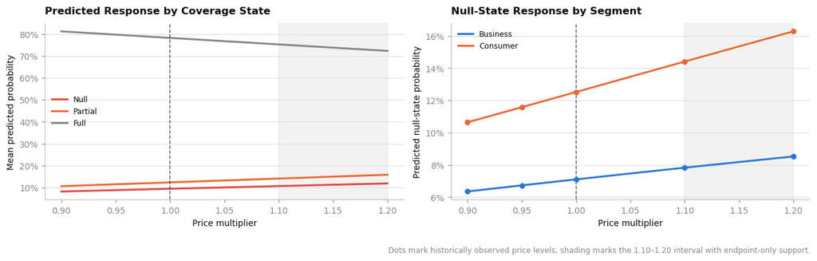

Modeled Null-State Response Across the Price Range

| Segment | P(null) at 0.90 | P(null) at 1.20 | Range Swing |
| --- | --- | --- | --- |
| Business | 6.3% | 8.5% | +2.2% |
| Consumer | 10.6% | 16.3% | +5.6% |

Observed Null-State Rate by Segment and Price

| Segment | 0.90 | 0.95 | 1.00 | 1.10 | 1.20 |
| --- | --- | --- | --- | --- | --- |
| Consumer | 11.0% | 12.0% | 12.7% | 17.3% | 22.3% |
| Business | 7.4% | 7.0% | 7.2% | 8.6% | 9.4% |

```python
# Evaluate Raw Price Response
GRID = np.round(np.linspace(0.90, 1.20, 25), 4)
OBS_PRICES = [0.90, 0.95, 1.00, 1.10, 1.20]
SWEEP_SIGN = {'null': 1, 'partial': 1, 'full': -1}

sweep = pd.DataFrame([
    {
        **dict(
            zip(
                CLASSES,
                raw_score(
                    X[te],
                    trips[te],
                    multiplier,
                ).mean(axis=0),
            )
        ),
        'price_multiplier': multiplier,
    }
    for multiplier in GRID
]).set_index('price_multiplier')

sweep_display = (
    sweep.iloc[::4]
    .rename_axis('Price Multiplier')
    .reset_index()
    .rename(columns={
        'null': 'Null',
        'partial': 'Partial',
        'full': 'Full',
    })
)

display(
    sweep_display.style
    .hide(axis='index')
    .format({
        'Price Multiplier': '{:.2f}',
        'Null': '{:.1%}',
        'Partial': '{:.1%}',
        'Full': '{:.1%}',
    })
    .set_caption('Modeled Coverage-State Response by Price')
    .set_table_styles(
        TABLE_STYLES + [
            {
                'selector': 'td.col0, td.col1, td.col2, td.col3',
                'props': [('text-align', 'right !important')],
            },
        ]
    )
)

violations = {
    coverage_class: int(
        (
            sweep[coverage_class].diff().dropna()
            * SWEEP_SIGN[coverage_class]
            < -1e-9
        ).sum()
    )
    for coverage_class in CLASSES
}

flat_steps = {
    coverage_class: int(
        (
            sweep[coverage_class]
            .diff()
            .abs()
            .dropna()
            < 1e-9
        ).sum()
    )
    for coverage_class in CLASSES
}

expected_coverage = (
    sweep['full']
    + 0.5 * sweep['partial']
)

coverage_violations = int(
    (expected_coverage.diff().dropna() > 1e-9).sum()
)

maximum_sum_error = (
    sweep.sum(axis=1)
    .sub(1.0)
    .abs()
    .max()
)

assert all(
    value == 0
    for value in violations.values()
), f'monotonicity violation found: {violations}'

assert coverage_violations == 0, (
    'expected coverage increased somewhere in the sweep'
)

assert np.allclose(
    sweep.sum(axis=1),
    1.0,
    atol=1e-6,
), 'sweep probabilities do not sum to one'

sweep_audit = pd.DataFrame({
    'Validation': [
        'Null-state monotonicity',
        'Partial-state monotonicity',
        'Full-state monotonicity',
        'Expected-coverage monotonicity',
        'Probability sum',
        'Flat-step check',
    ],
    'Status': [
        'Pass' if violations['null'] == 0 else 'Review',
        'Pass' if violations['partial'] == 0 else 'Review',
        'Pass' if violations['full'] == 0 else 'Review',
        'Pass' if coverage_violations == 0 else 'Review',
        'Pass' if maximum_sum_error <= 1e-6 else 'Review',
        'Pass' if sum(flat_steps.values()) == 0 else 'Review',
    ],
    'Result': [
        f"{violations['null']} decreases",
        f"{violations['partial']} decreases",
        f"{violations['full']} increases",
        f'{coverage_violations} increases',
        f'Maximum error: {maximum_sum_error:.2e}',
        f'{sum(flat_steps.values())} flat steps',
    ],
})


def audit_status_style(value):
    if value == 'Pass':
        return 'color: #237a3b; font-weight: bold'
    return 'color: #b23c17; font-weight: bold'


display(
    sweep_audit.style
    .hide(axis='index')
    .set_caption('Raw Price-Response Validation')
    .map(
        audit_status_style,
        subset=['Status'],
    )
    .set_table_styles(TABLE_STYLES)
)

i_null = IDX['null']
test_business = trips.loc[
    te, 'is_business'
].to_numpy(dtype=int)

segment_curves = {}

for segment_value, segment_name in [
    (1, 'Business'),
    (0, 'Consumer'),
]:
    mask = test_business == segment_value

    segment_curves[segment_name] = np.array([
        raw_score(
            X[te][mask],
            trips[te][mask],
            multiplier,
        )[:, i_null].mean()
        for multiplier in GRID
    ])

fig, axes = plt.subplots(
    1,
    2,
    figsize=(12, 3.8),
)

state_colors = {
    'null': RED,
    'partial': ACCENT2,
    'full': MUTED,
}

for coverage_class in CLASSES:
    axes[0].plot(
        sweep.index,
        sweep[coverage_class],
        color=state_colors[coverage_class],
        linewidth=2,
        label=coverage_class.title(),
    )

axes[0].axvline(
    1.0,
    color=INK,
    linestyle='--',
    linewidth=1,
    alpha=0.65,
)

axes[0].axvspan(
    1.10,
    1.20,
    color=INK,
    alpha=0.05,
)

axes[0].set(
    xlabel='Price multiplier',
    ylabel='Mean predicted probability',
)

axes[0].set_title(
    'Predicted Response by Coverage State',
    loc='left',
    fontweight='bold',
    pad=10,
)

axes[0].yaxis.set_major_formatter(
    lambda value, position: f'{value:.0%}'
)

axes[0].grid(
    axis='y',
    color=GRIDLINE,
    linewidth=0.8,
)

axes[0].legend(
    frameon=False,
    fontsize=8,
)

segment_colors = {
    'Business': ACCENT,
    'Consumer': ACCENT2,
}

for segment_name, curve in segment_curves.items():
    axes[1].plot(
        GRID,
        curve,
        color=segment_colors[segment_name],
        linewidth=2,
        label=segment_name,
    )

    observed_curve = np.interp(
        OBS_PRICES,
        GRID,
        curve,
    )

    axes[1].scatter(
        OBS_PRICES,
        observed_curve,
        color=segment_colors[segment_name],
        s=24,
        zorder=3,
    )

axes[1].axvline(
    1.0,
    color=INK,
    linestyle='--',
    linewidth=1,
    alpha=0.65,
)

axes[1].axvspan(
    1.10,
    1.20,
    color=INK,
    alpha=0.05,
)

axes[1].set(
    xlabel='Price multiplier',
    ylabel='Predicted null-state probability',
)

axes[1].set_title(
    'Null-State Response by Segment',
    loc='left',
    fontweight='bold',
    pad=10,
)

axes[1].yaxis.set_major_formatter(
    lambda value, position: f'{value:.0%}'
)

axes[1].grid(
    axis='y',
    color=GRIDLINE,
    linewidth=0.8,
)

axes[1].legend(
    frameon=False,
    fontsize=8,
)

fig.text(
    0.99,
    0.02,
    'Dots mark historically observed price levels; shading marks the '
    '1.10–1.20 interval with endpoint-only support.',
    ha='right',
    color=MUTED,
    fontsize=8,
)

plt.tight_layout(rect=[0, 0.08, 1, 1])
plt.show()

segment_summary = pd.DataFrame([
    {
        'Segment': segment_name,
        'P(null) at 0.90': curve[0],
        'P(null) at 1.20': curve[-1],
        'Range Swing': curve[-1] - curve[0],
    }
    for segment_name, curve in segment_curves.items()
])

display(
    segment_summary.style
    .hide(axis='index')
    .format({
        'P(null) at 0.90': '{:.1%}',
        'P(null) at 1.20': '{:.1%}',
        'Range Swing': '{:+.1%}',
    })
    .set_caption('Modeled Null-State Response Across the Price Range')
    .set_table_styles(
        TABLE_STYLES + [
            {
                'selector': 'td.col1, td.col2, td.col3',
                'props': [('text-align', 'right !important')],
            },
        ]
    )
)

observed_null = (
    trips.assign(
        null_state=trips['y'].eq('null').astype(float)
    )
    .pivot_table(
        index='is_business',
        columns='price_multiplier',
        values='null_state',
    )
    .reindex(columns=OBS_PRICES)
    .rename(index={
        0: 'Consumer',
        1: 'Business',
        False: 'Consumer',
        True: 'Business',
    })
    .rename_axis('Segment')
    .reset_index()
)

observed_null.columns = [
    'Segment',
    *[f'{price:.2f}' for price in OBS_PRICES],
]

observed_price_columns = [
    f'{price:.2f}'
    for price in OBS_PRICES
]

display(
    observed_null.style
    .hide(axis='index')
    .format({
        column: '{:.1%}'
        for column in observed_price_columns
    })
    .set_caption('Observed Null-State Rate by Segment and Price')
    .set_table_styles(
        TABLE_STYLES + [
            {
                'selector': 'td.col1, td.col2, td.col3, td.col4, td.col5',
                'props': [('text-align', 'right !important')],
            },
        ]
    )
)
```

### 6.2 · Regional Price-Response Holdout

**Purpose:** Tests whether the price response estimated from other regions transfers to Asia-Pacific. This complements the temporal holdout by evaluating geographic generalization of the price effect.

   $$ \text{response ratio} = \frac{\text{observed change from the standard price}} {\text{predicted change from the standard price}} $$

   A ratio above 1 indicates that the observed customer response is stronger than the model predicts.
4. **Uncertainty.** Observed and predicted rates, response slopes, and their ratio should be reported with sample sizes and uncertainty intervals. The ratio should be interpreted cautiously when the predicted change is small.
5. **Simulation Sensitivity.** The regional holdout is used to create two simulation scenarios:
   - **Base Response.** Uses the fitted Stage 2 price coefficients without adjustment.
   - **Stronger-Response Sensitivity.** Increases the Stage 2 price response using the holdout ratio.

   The sensitivity factor is applied to the Stage 2 log-price terms, not directly to the final probabilities:

   $$ \eta_c^{(s)} = \log P_c^{(1)} + s\left( \beta_c\ell + \gamma_c\ell I_{\text{business}} \right) $$

```python
# Regional Holdout
i_null = IDX['null']

is_asia_pacific = trips['region'].isin([
    'asia',
    'oceania',
]).to_numpy()

h_tr = tr & ~is_asia_pacific
h_s1 = h_tr & trips['price_multiplier'].eq(1.0).to_numpy()
h_te = (
    is_asia_pacific
    & trips['month'].between(8, 15).to_numpy()
)

g_h = HistGradientBoostingClassifier(
    max_iter=400,
    learning_rate=0.06,
    max_leaf_nodes=31,
    min_samples_leaf=40,
    l2_regularization=1.0,
    early_stopping=True,
    validation_fraction=0.15,
    random_state=0,
).fit(X[h_s1], y[h_s1])

ord_h = [
    list(g_h.classes_).index(c)
    for c in CLASSES
]


def s1_h(Xf):
    P = g_h.predict_proba(Xf)[:, ord_h]
    P = np.clip(P, 1e-6, None)
    return P / P.sum(axis=1, keepdims=True)


res_h = minimize(
    nll,
    np.zeros(len(FIT_CLASSES) * len(TERMS)),
    args=(
        np.log(s1_h(X[h_tr])),
        price_design(trips[h_tr]),
        yi[h_tr],
    ),
    method='L-BFGS-B',
    bounds=bounds,
    options={'maxiter': 500},
)

if not res_h.success:
    raise RuntimeError(
        f'regional-holdout fit did not converge: {res_h.message}'
    )

B_h = res_h.x.reshape(
    len(FIT_CLASSES),
    len(TERMS),
)

eta_h = np.log(s1_h(X[h_te]))
Z_h = price_design(trips[h_te])

for k, coverage_class in enumerate(FIT_CLASSES):
    eta_h[:, IDX[coverage_class]] += Z_h @ B_h[k]

P_h = softmax(eta_h)

holdout_results = (
    pd.DataFrame({
        'Price Multiplier': trips.loc[
            h_te, 'price_multiplier'
        ].to_numpy(),
        'Predicted Null Rate': P_h[:, i_null],
        'Observed Null Rate': (
            y[h_te] == 'null'
        ).astype(float),
    })
    .groupby('Price Multiplier', as_index=False)
    .agg(
        Trips=('Observed Null Rate', 'size'),
        Predicted_Null_Rate=(
            'Predicted Null Rate',
            'mean',
        ),
        Observed_Null_Rate=(
            'Observed Null Rate',
            'mean',
        ),
    )
    .rename(columns={
        'Predicted_Null_Rate': 'Predicted Null Rate',
        'Observed_Null_Rate': 'Observed Null Rate',
    })
)

holdout_results['Prediction Gap'] = (
    holdout_results['Predicted Null Rate']
    - holdout_results['Observed Null Rate']
)

display(
    holdout_results.style
    .hide(axis='index')
    .format({
        'Price Multiplier': '{:.2f}',
        'Trips': '{:,.0f}',
        'Predicted Null Rate': '{:.1%}',
        'Observed Null Rate': '{:.1%}',
        'Prediction Gap': '{:+.1%}',
    })
    .set_caption('Asia-Pacific Regional Holdout: Null-State Response')
    .set_table_styles(
        TABLE_STYLES + [
            {
                'selector': (
                    'td.col0, td.col1, td.col2, td.col3, td.col4'
                ),
                'props': [('text-align', 'right !important')],
            },
        ]
    )
)

if len(holdout_results) >= 2:
    predicted_slope = (
        holdout_results['Predicted Null Rate'].iloc[-1]
        - holdout_results['Predicted Null Rate'].iloc[0]
    )

    observed_slope = (
        holdout_results['Observed Null Rate'].iloc[-1]
        - holdout_results['Observed Null Rate'].iloc[0]
    )

    RESPONSE_RATIO = (
        float(observed_slope / predicted_slope)
        if abs(predicted_slope) > 1e-9
        else np.nan
    )
else:
    predicted_slope = np.nan
    observed_slope = np.nan
    RESPONSE_RATIO = np.nan

if not np.isfinite(RESPONSE_RATIO):
    assessment = (
        'Insufficient price variation to estimate '
        'a response ratio'
    )
elif RESPONSE_RATIO > 1.25:
    assessment = (
        'Observed response is stronger; retain the fitted '
        'and stronger-response sensitivity scenarios'
    )
elif RESPONSE_RATIO < 0.80:
    assessment = (
        'Observed response is weaker; retain both response '
        'scenarios for sensitivity testing'
    )
else:
    assessment = (
        'Observed and predicted responses are broadly aligned'
    )

response_summary = pd.DataFrame({
    'Predicted Change': [predicted_slope],
    'Observed Change': [observed_slope],
    'Observed / Predicted': [RESPONSE_RATIO],
    'Assessment': [assessment],
})

display(
    response_summary.style
    .hide(axis='index')
    .format({
        'Predicted Change': '{:+.1%}',
        'Observed Change': '{:+.1%}',
        'Observed / Predicted': (
            lambda value: (
                f'{value:.2f}×'
                if np.isfinite(value)
                else 'Not available'
            )
        ),
    })
    .set_caption('Response Across the Held-Out Price Levels')
    .set_properties(
        subset=['Observed / Predicted'],
        **{
            'color': ACCENT,
            'font-weight': 'bold',
        },
    )
    .set_table_styles(
        TABLE_STYLES + [
            {
                'selector': 'td.col0, td.col1, td.col2',
                'props': [('text-align', 'right !important')],
            },
            {
                'selector': 'td.col3',
                'props': [('text-align', 'left !important')],
            },
        ]
    )
)
```

Asia-Pacific Regional Holdout: Null-State Response

| Price Multiplier | Trips | Predicted Null Rate | Observed Null Rate | Prediction Gap |
| --- | --- | --- | --- | --- |
| 1.10 | 2,687 | 9.0% | 11.8% | -2.8% |
| 1.20 | 2,759 | 9.9% | 13.3% | -3.4% |

Response Across the Held-Out Price Levels

| Predicted Change | Observed Change | Observed / Predicted | Assessment |
| --- | --- | --- | --- |
| +0.9% | +1.5% | 1.76× | Observed response is stronger; retain the fitted and stronger-response sensitivity scenarios |